### Packages & Libraries

```r
library(corrplot)
library(ggplot2)
library(caret)
library(mlbench)
library(ROCR)
library(party)
library(rpart)
```

### Preprocessing

```r
data <- read.csv("bank-additional-full.csv",sep=";")
head(data)
```

```
##   age       job marital   education default housing loan   contact month
## 1  56 housemaid married    basic.4y      no      no   no telephone   may
## 2  57  services married high.school unknown      no   no telephone   may
## 3  37  services married high.school      no     yes   no telephone   may
## 4  40    admin. married    basic.6y      no      no   no telephone   may
## 5  56  services married high.school      no      no  yes telephone   may
## 6  45  services married    basic.9y unknown      no   no telephone   may
##   day_of_week duration campaign pdays previous    poutcome emp.var.rate
## 1         mon      261        1   999        0 nonexistent          1.1
## 2         mon      149        1   999        0 nonexistent          1.1
## 3         mon      226        1   999        0 nonexistent          1.1
## 4         mon      151        1   999        0 nonexistent          1.1
## 5         mon      307        1   999        0 nonexistent          1.1
## 6         mon      198        1   999        0 nonexistent          1.1
##   cons.price.idx cons.conf.idx euribor3m nr.employed  y
## 1         93.994         -36.4     4.857        5191 no
## 2         93.994         -36.4     4.857        5191 no
## 3         93.994         -36.4     4.857        5191 no
## 4         93.994         -36.4     4.857        5191 no
## 5         93.994         -36.4     4.857        5191 no
## 6         93.994         -36.4     4.857        5191 no
```

showing row count

```r
cat("Original row count is",nrow(data))
```

```
## Original row count is 41188
```

dropping ‘duration’,‘pdays’,‘default’

```r
data <- subset(data, select = -c(duration, pdays, default))
colnames(data)
```

```
##  [1] "age"            "job"            "marital"        "education"
##  [5] "housing"        "loan"           "contact"        "month"
##  [9] "day_of_week"    "campaign"       "previous"       "poutcome"
## [13] "emp.var.rate"   "cons.price.idx" "cons.conf.idx"  "euribor3m"
## [17] "nr.employed"    "y"
```

find the columns that have “unknown” as a value

```r
has_unknown <- function(df, col) {
  (sum(df[,col]=="unknown")>0)
}
where_is_unknown <- function(df) {
  c <- 0
  for(col in colnames(df)) {
    if (has_unknown(df,col)) {
      cat(col)
      c <- c + 1
    }
  }
  if(c == 0) {
    print(paste("There are no unknown values in the dataframe"))
  }
}
print(paste("These columns have unknown values"))
```

```
## [1] "These columns have unknown values"
```

```r
where_is_unknown(data)
```

```
## jobmaritaleducationhousingloan
```

replace those “unknown” values with a sample of the other values in those columns

```r
replace_unknowns <- function(df) {
  for(col in colnames(df)) {
    if(has_unknown(df,col)) {
      n_unk <- sum(df[,col]=="unknown")
      idx <- which(df[,col]=="unknown")
      df[idx,col] <- sample(col[!col=="unknown"],n_unk,replace=TRUE)
    }
  }
  df
}
data <- replace_unknowns(data)
head(data)
```

```
##   age       job marital   education housing loan   contact month day_of_week
## 1  56 housemaid married    basic.4y      no   no telephone   may         mon
## 2  57  services married high.school      no   no telephone   may         mon
## 3  37  services married high.school     yes   no telephone   may         mon
## 4  40    admin. married    basic.6y      no   no telephone   may         mon
## 5  56  services married high.school      no  yes telephone   may         mon
## 6  45  services married    basic.9y      no   no telephone   may         mon
##   campaign previous    poutcome emp.var.rate cons.price.idx cons.conf.idx
## 1        1        0 nonexistent          1.1         93.994         -36.4
## 2        1        0 nonexistent          1.1         93.994         -36.4
## 3        1        0 nonexistent          1.1         93.994         -36.4
## 4        1        0 nonexistent          1.1         93.994         -36.4
## 5        1        0 nonexistent          1.1         93.994         -36.4
## 6        1        0 nonexistent          1.1         93.994         -36.4
##   euribor3m nr.employed  y
## 1     4.857        5191 no
## 2     4.857        5191 no
## 3     4.857        5191 no
## 4     4.857        5191 no
## 5     4.857        5191 no
## 6     4.857        5191 no
```

just to make sure those values were actually replaced and now there’s no more unknowns

```r
cat("# of unknowns:", sum(data=="unknown"))
```

```
## # of unknowns: 0
```

show the categorical columns

```r
cats <- names(data)[sapply(data,is.character)]
cats
```

```
##  [1] "job"         "marital"     "education"   "housing"     "loan"
##  [6] "contact"     "month"       "day_of_week" "poutcome"    "y"
```

encode all of the categorical values into numericals

```r
encode <- function(df,col) {
  as.numeric(factor(df[,col]))-1
}
for(cat in cats) {
  data[,cat] <- encode(data,cat)
}
head(data)
```

```
##   age job marital education housing loan contact month day_of_week campaign
## 1  56   3       2         0       1    1       1     6           1        1
## 2  57   8       2         4       1    1       1     6           1        1
## 3  37   8       2         4       2    1       1     6           1        1
## 4  40   0       2         1       1    1       1     6           1        1
## 5  56   8       2         4       1    2       1     6           1        1
## 6  45   8       2         2       1    1       1     6           1        1
##   previous poutcome emp.var.rate cons.price.idx cons.conf.idx euribor3m
## 1        0        1          1.1         93.994         -36.4     4.857
## 2        0        1          1.1         93.994         -36.4     4.857
## 3        0        1          1.1         93.994         -36.4     4.857
## 4        0        1          1.1         93.994         -36.4     4.857
## 5        0        1          1.1         93.994         -36.4     4.857
## 6        0        1          1.1         93.994         -36.4     4.857
##   nr.employed y
## 1        5191 0
## 2        5191 0
## 3        5191 0
## 4        5191 0
## 5        5191 0
## 6        5191 0
```

count plot for target to check for imbalance

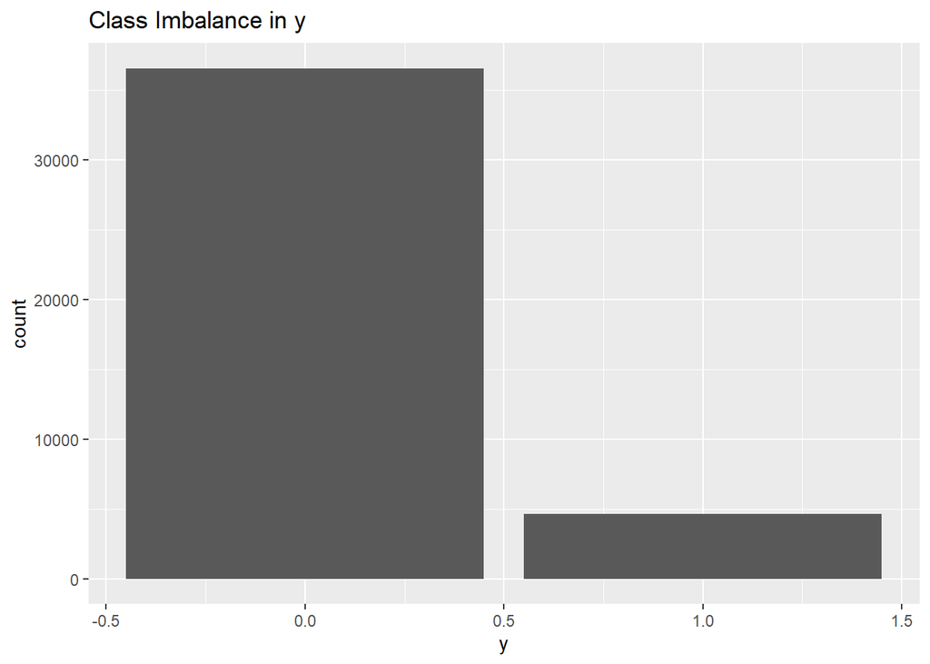

```r
plt <- ggplot(data, aes(x = y)) + geom_bar(size=6)
plt + ggtitle("\t\t\t\tClass Imbalance in y")
```

Fixing the class imbalance by oversampling & resetting dataframe

```r
data$y <- factor(data$y)
data <- upSample(x=data[,-ncol(data)],y=data$y)
names(data)[names(data)=='Class'] <- 'y'
```

count plot for target to ensure classes have been balanced

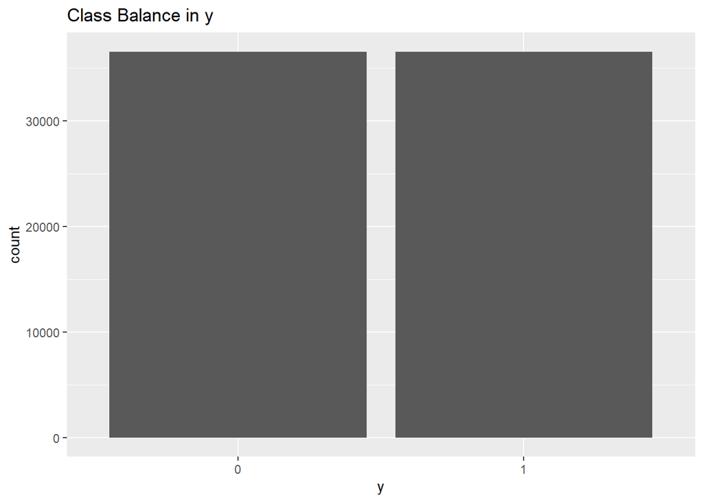

```r
plt <- ggplot(data, aes(x = y)) + geom_bar(size=6)
plt + ggtitle("\t\t\t\tClass Balance in y")
```

checking for NA’s

```r
print(paste("# of NA's", sum(is.na(data))))
```

```
## [1] "# of NA's 0"
```

checking for unknowns

```r
where_is_unknown(data)
```

```
## [1] "There are no unknown values in the dataframe"
```

since there are no unknown values and no NA’s, lastly checking for increase in row count in dataframe

```r
cat("New row count is",nrow(data))
```

```
## New row count is 73096
```

#### Train Test Split

splitting 80/20 into train and test

```r
set.seed(3)
i <- sample(1:nrow(data), nrow(data)*0.80, replace = FALSE)
train <- data[i,]
test <- data[-i,]
dim(train)
```

```
## [1] 58476    18
```

```r
dim(test)
```

```
## [1] 14620    18
```

### General EDA

plotting correlation matrix

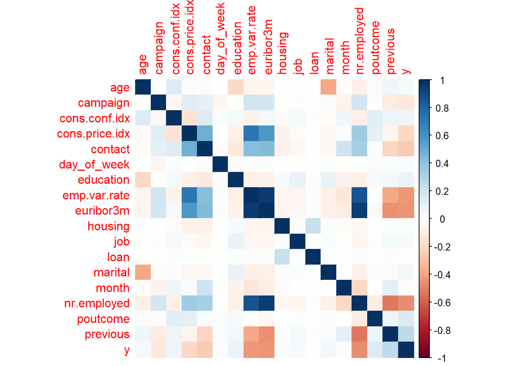

```r
train$y <- encode(train,'y')
C <- cor(train)
corrplot(C, method='color', order = 'alphabet')
```

looking more specifically relative to ‘y’

```r
C[,'y']
```

```
##            age            job        marital      education        housing
##    0.046107743    0.035143070    0.057777267    0.084504069    0.018642182
##           loan        contact          month    day_of_week       campaign
##   -0.006671974   -0.251624466   -0.015343921    0.024417799   -0.122269619
##       previous       poutcome   emp.var.rate cons.price.idx  cons.conf.idx
##    0.258111161    0.159164858   -0.431911309   -0.202178067    0.070130264
##      euribor3m    nr.employed              y
##   -0.447676664   -0.465113451    1.000000000
```

it looks like euribor3m, nr.employed, emp.var.rate have the strongest negative correlation with y, and previous and poutcome, have the strongest positive correlation.

### Linear Regression

to explore more, making base model for all independents against ‘y’

```r
set.seed(10)
base <- lm(y~.,data=train)
summary(base)
```

```
##
## Call:
## lm(formula = y ~ ., data = train)
##
## Residuals:
##     Min      1Q  Median      3Q     Max
## -1.1273 -0.3153 -0.1176  0.3141  0.8941
##
## Coefficients:
##                  Estimate Std. Error t value Pr(>|t|)
## (Intercept)    -2.0816386  1.5115669  -1.377 0.168474
## age             0.0005474  0.0001663   3.291 0.000999 ***
## job             0.0001216  0.0004450   0.273 0.784721
## marital         0.0121864  0.0022626   5.386 7.23e-08 ***
## education       0.0056012  0.0007680   7.293 3.07e-13 ***
## housing        -0.0071672  0.0033633  -2.131 0.033094 *
## loan            0.0009185  0.0046140   0.199 0.842209
## contact        -0.1397961  0.0054630 -25.590  < 2e-16 ***
## month          -0.0233969  0.0009088 -25.746  < 2e-16 ***
## day_of_week     0.0069071  0.0012761   5.413 6.23e-08 ***
## campaign       -0.0060903  0.0007680  -7.930 2.23e-15 ***
## previous        0.0080118  0.0030806   2.601 0.009305 **
## poutcome        0.1165421  0.0039332  29.630  < 2e-16 ***
## emp.var.rate   -0.1901645  0.0062235 -30.556  < 2e-16 ***
## cons.price.idx  0.1421533  0.0093586  15.190  < 2e-16 ***
## cons.conf.idx   0.0010424  0.0005909   1.764 0.077733 .
## euribor3m       0.1308574  0.0088761  14.743  < 2e-16 ***
## nr.employed    -0.0021787  0.0001501 -14.517  < 2e-16 ***
## ---
## Signif. codes:  0 '***' 0.001 '**' 0.01 '*' 0.05 '.' 0.1 ' ' 1
##
## Residual standard error: 0.4292 on 58458 degrees of freedom
## Multiple R-squared:  0.2635, Adjusted R-squared:  0.2633
## F-statistic:  1230 on 17 and 58458 DF,  p-value: < 2.2e-16
```

```r
set.seed(11)
m1 <- lm(y~.,data=subset(train,select = -c(age,job,housing,loan)))
summary(m1)
```

```
##
## Call:
## lm(formula = y ~ ., data = subset(train, select = -c(age, job,
##     housing, loan)))
##
## Residuals:
##     Min      1Q  Median      3Q     Max
## -1.1319 -0.3157 -0.1184  0.3139  0.8993
##
## Coefficients:
##                  Estimate Std. Error t value Pr(>|t|)
## (Intercept)    -1.9755586  1.5077513  -1.310  0.19011
## marital         0.0093037  0.0020873   4.457 8.31e-06 ***
## education       0.0050669  0.0007489   6.765 1.34e-11 ***
## contact        -0.1398410  0.0054617 -25.604  < 2e-16 ***
## month          -0.0236027  0.0009051 -26.076  < 2e-16 ***
## day_of_week     0.0068871  0.0012761   5.397 6.81e-08 ***
## campaign       -0.0060699  0.0007680  -7.903 2.76e-15 ***
## previous        0.0081852  0.0030803   2.657  0.00788 **
## poutcome        0.1164947  0.0039330  29.619  < 2e-16 ***
## emp.var.rate   -0.1908425  0.0062211 -30.676  < 2e-16 ***
## cons.price.idx  0.1424701  0.0093468  15.243  < 2e-16 ***
## cons.conf.idx   0.0011867  0.0005898   2.012  0.04422 *
## euribor3m       0.1320735  0.0088593  14.908  < 2e-16 ***
## nr.employed    -0.0022004  0.0001496 -14.707  < 2e-16 ***
## ---
## Signif. codes:  0 '***' 0.001 '**' 0.01 '*' 0.05 '.' 0.1 ' ' 1
##
## Residual standard error: 0.4292 on 58462 degrees of freedom
## Multiple R-squared:  0.2633, Adjusted R-squared:  0.2631
## F-statistic:  1607 on 13 and 58462 DF,  p-value: < 2.2e-16
```

every predictor is significant to the regression, but still R^2 is low. let’s see if scaling the independents help at all

```r
minMaxScaler <- function(v) {
  (v-min(v))/(max(v)-min(v))
}
```

```r
train_scaled <- subset(train,select = -c(age,job,housing,loan))
train_scaled[,-ncol(train_scaled)] <- lapply(train_scaled[, -ncol(train_scaled)],minMaxScaler)
head(train_scaled)
```

```
##         marital education contact     month day_of_week   campaign previous
## 52922 1.0000000 1.0000000       0 0.6666667        0.25 0.00000000        0
## 41352 0.6666667 0.0000000       1 0.4444444        0.50 0.01818182        0
## 36520 0.6666667 1.0000000       0 0.7777778        0.50 0.00000000        0
## 66541 0.6666667 1.0000000       0 1.0000000        0.00 0.01818182        0
## 6120  1.0000000 0.5714286       1 0.6666667        0.75 0.05454545        0
## 51849 0.6666667 1.0000000       0 0.6666667        0.25 0.01818182        0
##       poutcome emp.var.rate cons.price.idx cons.conf.idx  euribor3m nr.employed
## 52922      0.5    0.3333333     0.26968044     0.1924686 0.15075946   0.5122873
## 41352      0.5    1.0000000     0.88230709     0.3765690 0.98027658   1.0000000
## 36520      0.5    0.4791667     1.00000000     0.0000000 0.09226933   0.0000000
## 66541      0.5    0.0000000     0.06936867     0.8786611 0.02901836   0.2037807
## 6120       0.5    0.9375000     0.69875292     0.6025105 0.95737928   0.8597353
## 51849      0.5    0.3333333     0.26968044     0.1924686 0.15075946   0.5122873
##       y
## 52922 1
## 41352 1
## 36520 0
## 66541 1
## 6120  0
## 51849 1
```

```r
set.seed(13)
m2 <- lm(y~.,data=train_scaled)
summary(m2)
```

```
##
## Call:
## lm(formula = y ~ ., data = train_scaled)
##
## Residuals:
##     Min      1Q  Median      3Q     Max
## -1.1319 -0.3157 -0.1184  0.3139  0.8993
##
## Coefficients:
##                 Estimate Std. Error t value Pr(>|t|)
## (Intercept)     0.904535   0.025729  35.156  < 2e-16 ***
## marital         0.027911   0.006262   4.457 8.31e-06 ***
## education       0.035469   0.005243   6.765 1.34e-11 ***
## contact        -0.139841   0.005462 -25.604  < 2e-16 ***
## month          -0.212424   0.008146 -26.076  < 2e-16 ***
## day_of_week     0.027548   0.005105   5.397 6.81e-08 ***
## campaign       -0.333842   0.042241  -7.903 2.76e-15 ***
## previous        0.057296   0.021562   2.657  0.00788 **
## poutcome        0.232989   0.007866  29.619  < 2e-16 ***
## emp.var.rate   -0.916044   0.029862 -30.676  < 2e-16 ***
## cons.price.idx  0.365578   0.023984  15.243  < 2e-16 ***
## cons.conf.idx   0.028362   0.014096   2.012  0.04422 *
## euribor3m       0.582576   0.039079  14.908  < 2e-16 ***
## nr.employed    -0.582013   0.039573 -14.707  < 2e-16 ***
## ---
## Signif. codes:  0 '***' 0.001 '**' 0.01 '*' 0.05 '.' 0.1 ' ' 1
##
## Residual standard error: 0.4292 on 58462 degrees of freedom
## Multiple R-squared:  0.2633, Adjusted R-squared:  0.2631
## F-statistic:  1607 on 13 and 58462 DF,  p-value: < 2.2e-16
```

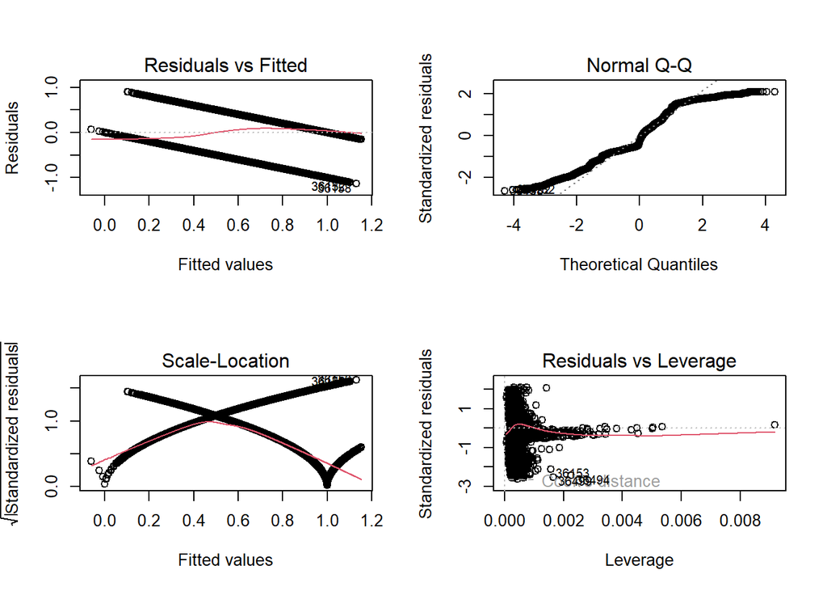

```r
par(mfrow=c(2,2))
plot(m2)
```

```r
par(mfrow=c(1,1))
```

true to form, scaling does not impact the regression results. Both R^2 and the adjusted R^2 are staying low. we will use the model ‘m1’ for prediction as ‘m2’ doesn’t appear to be doing much better.

#### Linear Regression Evaluation

create model for ‘m1’ once again (no scaling)

```r
set.seed(11)
m1 <- lm(y~.,data=subset(train,select = -c(age,job,housing,loan)))
summary(m1)
```

```
##
## Call:
## lm(formula = y ~ ., data = subset(train, select = -c(age, job,
##     housing, loan)))
##
## Residuals:
##     Min      1Q  Median      3Q     Max
## -1.1319 -0.3157 -0.1184  0.3139  0.8993
##
## Coefficients:
##                  Estimate Std. Error t value Pr(>|t|)
## (Intercept)    -1.9755586  1.5077513  -1.310  0.19011
## marital         0.0093037  0.0020873   4.457 8.31e-06 ***
## education       0.0050669  0.0007489   6.765 1.34e-11 ***
## contact        -0.1398410  0.0054617 -25.604  < 2e-16 ***
## month          -0.0236027  0.0009051 -26.076  < 2e-16 ***
## day_of_week     0.0068871  0.0012761   5.397 6.81e-08 ***
## campaign       -0.0060699  0.0007680  -7.903 2.76e-15 ***
## previous        0.0081852  0.0030803   2.657  0.00788 **
## poutcome        0.1164947  0.0039330  29.619  < 2e-16 ***
## emp.var.rate   -0.1908425  0.0062211 -30.676  < 2e-16 ***
## cons.price.idx  0.1424701  0.0093468  15.243  < 2e-16 ***
## cons.conf.idx   0.0011867  0.0005898   2.012  0.04422 *
## euribor3m       0.1320735  0.0088593  14.908  < 2e-16 ***
## nr.employed    -0.0022004  0.0001496 -14.707  < 2e-16 ***
## ---
## Signif. codes:  0 '***' 0.001 '**' 0.01 '*' 0.05 '.' 0.1 ' ' 1
##
## Residual standard error: 0.4292 on 58462 degrees of freedom
## Multiple R-squared:  0.2633, Adjusted R-squared:  0.2631
## F-statistic:  1607 on 13 and 58462 DF,  p-value: < 2.2e-16
```

get predictions and measure accuracy

```r
set.seed(21)
probas <- predict(m1, newdata = test, type="response")
pred <- ifelse(probas>0.5, 1, 0)
acc <- mean(pred==test$y)
print(paste("Accuracy = ", round(acc,3)))
```

```
## [1] "Accuracy =  0.734"
```

```r
print(paste("Correlation = ",round(cor(probas,as.numeric(test$y)-1),3)))
```

```
## [1] "Correlation =  0.517"
```

construct confusion matrix for easy visualization

```r
confusionMatrix(as.factor(pred), reference=test$y)
```

```
## Confusion Matrix and Statistics
##
##           Reference
## Prediction    0    1
##          0 5883 2410
##          1 1483 4844
##
##                Accuracy : 0.7337
##                  95% CI : (0.7265, 0.7409)
##     No Information Rate : 0.5038
##     P-Value [Acc > NIR] : < 2.2e-16
##
##                   Kappa : 0.4669
##
##  Mcnemar's Test P-Value : < 2.2e-16
##
##             Sensitivity : 0.7987
##             Specificity : 0.6678
##          Pos Pred Value : 0.7094
##          Neg Pred Value : 0.7656
##              Prevalence : 0.5038
##          Detection Rate : 0.4024
##    Detection Prevalence : 0.5672
##       Balanced Accuracy : 0.7332
##
##        'Positive' Class : 0
##
```

construct ROC plot & show auc

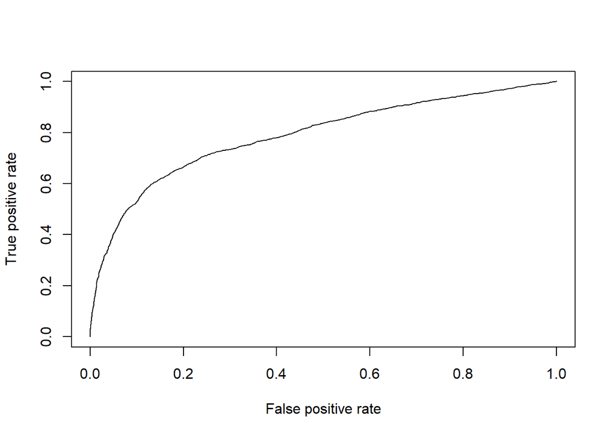

```r
set.seed(31)
pred <- prediction(probas,test$y)
roc <- performance(pred, measure="tpr", x.measure="fpr")
plot(roc)
```

```r
cat("auc =", round(performance(pred,measure="auc")@y.values[[1]],3))
```

```
## auc = 0.789
```

Overall, the linear regression model was predicting at around 73% accuracy. The correlation is around 51%. The model seemed to be able to distinguish between positive and negative classes for the ‘y’ feature though, with auc of about 78%.

Let’s see if KNN regression can do more justice.

### KNN Regression

For KNN we will use the scaled version of the training sample. We will need to scale everything in test as well except for the the target ‘y’

```r
test_scaled <- subset(test,select = -c(age,job,housing,loan))
test_scaled[,-ncol(test_scaled)] <- lapply(test_scaled[, -ncol(test_scaled)],minMaxScaler)
```

Fit the scaled training data to the model

```r
kr1 <- knnreg(train_scaled[,-ncol(train_scaled)], train_scaled[,'y'])
summary(kr1)
```

```
##         Length Class  Mode
## learn   2      -none- list
## k       1      -none- numeric
## theDots 0      -none- list
```

```r
probas <- predict(kr1, newdata = test_scaled[,-ncol(test_scaled)], type="response")
pred <- ifelse(probas>0.5, 1, 0)
cor_kr1 <- cor(pred,as.numeric(test$y)-1)
cat("correlation=", round(cor_kr1,3))
```

```
## correlation= 0.58
```

construct confusion matrix for easy visualization

```r
confusionMatrix(as.factor(pred), reference=test$y)
```

```
## Confusion Matrix and Statistics
##
##           Reference
## Prediction    0    1
##          0 5316 1061
##          1 2050 6193
##
##                Accuracy : 0.7872
##                  95% CI : (0.7805, 0.7938)
##     No Information Rate : 0.5038
##     P-Value [Acc > NIR] : < 2.2e-16
##
##                   Kappa : 0.5748
##
##  Mcnemar's Test P-Value : < 2.2e-16
##
##             Sensitivity : 0.7217
##             Specificity : 0.8537
##          Pos Pred Value : 0.8336
##          Neg Pred Value : 0.7513
##              Prevalence : 0.5038
##          Detection Rate : 0.3636
##    Detection Prevalence : 0.4362
##       Balanced Accuracy : 0.7877
##
##        'Positive' Class : 0
##
```

Correlation went up, let’s see if we can select the best k to maximize it & minimize mse

```r
cor_kr <- rep(0,20)
mse_kr <- rep(0,20)
test_y_num <- encode(test,'y')
i <- 1
for(k in seq(1,39,2)) {
  fit_k <- knnreg(train_scaled[,-ncol(train_scaled)], train_scaled$y, k=k)
  pred_k <- predict(fit_k, test_scaled[,-ncol(test_scaled)])
  cor_kr[i] <- cor(pred_k,test_y_num)
  mse_kr[i] <- mean((pred_k - test_y_num)^2)
  print(paste("k=",k,cor_kr[i],mse_kr[i]))
  i <- i+1
}
```

```
## [1] "k= 1 0.672662137176505 0.145840936163736"
## [1] "k= 3 0.673373331517982 0.143475305629911"
## [1] "k= 5 0.666479243309595 0.144711449266465"
## [1] "k= 7 0.649378814829071 0.149514473081419"
## [1] "k= 9 0.636238940021903 0.152808874184051"
## [1] "k= 11 0.627449724289564 0.154717536697575"
## [1] "k= 13 0.616891987923931 0.157664650408855"
## [1] "k= 15 0.611331981818648 0.158983817826137"
## [1] "k= 17 0.604686739773698 0.160765634580465"
## [1] "k= 19 0.59965587597395 0.162027616125987"
## [1] "k= 21 0.595547310855708 0.163061979884042"
## [1] "k= 23 0.592438446343456 0.163803185961744"
## [1] "k= 25 0.588957078197201 0.164693503421484"
## [1] "k= 27 0.585417278890189 0.165621146763891"
## [1] "k= 29 0.583063098349186 0.166191320573982"
## [1] "k= 31 0.580692713639774 0.166763757333579"
## [1] "k= 33 0.579718733302671 0.166984239079339"
## [1] "k= 35 0.577622379780998 0.167507045157739"
## [1] "k= 37 0.576299697168428 0.167810092579285"
## [1] "k= 39 0.574639983447614 0.168251167470368"
```

## KNN Regression Evaluation

```r
fit_3 <- knnreg(train_scaled[,-ncol(train_scaled)], train_scaled$y, k=3)
summary(fit_3)
```

```
##         Length Class  Mode
## learn   2      -none- list
## k       1      -none- numeric
## theDots 0      -none- list
```

```r
predictions_3 <- predict(fit_3, test_scaled[,-ncol(test_scaled)])
cor_kr3 <- cor(predictions_3, test_y_num)
mse_kr3 <- mean((predictions_3 - test_y_num)^2)
print(paste("corr=", cor_kr3))
```

```
## [1] "corr= 0.673373331517982"
```

```r
print(paste("mse=", mse_kr3))
```

```
## [1] "mse= 0.143475305629911"
```

```r
set.seed(101)
km2 <- knnreg(y~., data=train_scaled, k=3)
probas <- predict(km2, newdata = test_scaled[,-ncol(test_scaled)], type="response")
pred <- ifelse(probas>0.5, 1, 0)
confusionMatrix(as.factor(pred), reference=test$y)
```

```
## Confusion Matrix and Statistics
##
##           Reference
## Prediction    0    1
##          0 5568 1115
##          1 1798 6139
##
##                Accuracy : 0.8008
##                  95% CI : (0.7942, 0.8072)
##     No Information Rate : 0.5038
##     P-Value [Acc > NIR] : < 2.2e-16
##
##                   Kappa : 0.6018
##
##  Mcnemar's Test P-Value : < 2.2e-16
##
##             Sensitivity : 0.7559
##             Specificity : 0.8463
##          Pos Pred Value : 0.8332
##          Neg Pred Value : 0.7735
##              Prevalence : 0.5038
##          Detection Rate : 0.3808
##    Detection Prevalence : 0.4571
##       Balanced Accuracy : 0.8011
##
##        'Positive' Class : 0
##
```

Using the k=3, there is a slight increase in the accuracy of our model. The sensitivity is lower than the specificity. Pointing at the model being about 8% better at predicting ‘yes’ (1) responses for the target y than ‘no’ (0) response for the target y. Which is pretty good considering that originally, it was that there were much more ‘no’ responses than ‘yes’, resulting in imbalance. The model is predicting at a decent rate and making fair guesses for each class of the target.

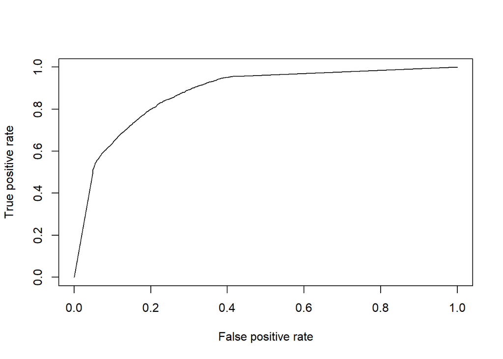

```r
set.seed(102)
pred <- prediction(probas,test_scaled$y)
roc <- performance(pred, measure="tpr", x.measure="fpr")
plot(roc)
```

```r
cat("auc =", round(performance(pred,measure="auc")@y.values[[1]],3))
```

```
## auc = 0.879
```

AUC ROC also increased with the change in the k value for knn. It jumped by nearly 10% after using the scaled features from the base model of knnregression as well as that for the best linear regression model we came up with.

### Decision Tree Regression

```r
fit_4 <- rpart(y~.,
               data=train)
```

```r
summary(fit_4)
```

```
## Call:
## rpart(formula = y ~ ., data = train)
##   n= 58476
##
##           CP nsplit rel error    xerror         xstd
## 1 0.19769087      0 1.0000000 1.0000258 1.854413e-05
## 2 0.04363300      1 0.8023091 0.8023463 2.961273e-03
## 3 0.01170061      2 0.7586761 0.7587571 3.310960e-03
## 4 0.01000000      3 0.7469755 0.7470615 3.327931e-03
##
## Variable importance
##    nr.employed      euribor3m  cons.conf.idx   emp.var.rate cons.price.idx
##             24             21             18             13             12
##       poutcome          month        contact
##              7              4              1
##
## Node number 1: 58476 observations,    complexity param=0.1976909
##   mean=0.5009577, MSE=0.2499991
##   left son=2 (42422 obs) right son=3 (16054 obs)
##   Primary splits:
##       nr.employed   < 5087.65 to the right, improve=0.19769090, (0 missing)
##       euribor3m     < 3.191   to the right, improve=0.18851610, (0 missing)
##       emp.var.rate  < -0.15   to the right, improve=0.18830730, (0 missing)
##       poutcome      < 1.5     to the left,  improve=0.08761088, (0 missing)
##       cons.conf.idx < -35.45  to the left,  improve=0.08085110, (0 missing)
##   Surrogate splits:
##       euribor3m      < 1.2395  to the right, agree=0.967, adj=0.880, (0 split)
##       emp.var.rate   < -2.35   to the right, agree=0.872, adj=0.535, (0 split)
##       cons.conf.idx  < -35.45  to the left,  agree=0.866, adj=0.510, (0 split)
##       cons.price.idx < 92.7345 to the right, agree=0.838, adj=0.408, (0 split)
##       poutcome       < 1.5     to the left,  agree=0.805, adj=0.289, (0 split)
##
## Node number 2: 42422 observations,    complexity param=0.043633
##   mean=0.3641978, MSE=0.2315578
##   left son=4 (36975 obs) right son=5 (5447 obs)
##   Primary splits:
##       cons.conf.idx  < -46.65  to the right, improve=0.06493527, (0 missing)
##       euribor3m      < 3.191   to the right, improve=0.06089732, (0 missing)
##       nr.employed    < 5183.65 to the right, improve=0.06074538, (0 missing)
##       emp.var.rate   < -0.15   to the right, improve=0.06074538, (0 missing)
```

[output cut: 18 more lines]

```
##       cons.conf.idx  < -44.3   to the right, improve=0.01814668, (0 missing)
##   Surrogate splits:
##       contact       < 0.5     to the right, agree=0.937, adj=0.806, (0 split)
##       cons.conf.idx < -41.9   to the right, agree=0.839, adj=0.502, (0 split)
##       month         < 3.5     to the right, agree=0.683, adj=0.020, (0 split)
##       campaign      < 20.5    to the right, agree=0.676, adj=0.001, (0 split)
##
## Node number 5: 5447 observations
##   mean=0.6836791, MSE=0.216262
##
## Node number 8: 11979 observations
##   mean=0.218883, MSE=0.1709733
##
## Node number 9: 24996 observations
##   mean=0.3642183, MSE=0.2315633
```

```r
predictions_4 <- predict(fit_4, test[,-ncol(test)])
cor_kr3 <- cor(predictions_4, test_y_num)
mse_kr3 <- mean((predictions_4 - test_y_num)^2)
print(paste("corr=", cor_kr3))
```

```
## [1] "corr= 0.504886095122061"
```

```r
print(paste("mse=", mse_kr3))
```

```
## [1] "mse= 0.186279600061473"
```

```r
pred <- ifelse(predictions_4>0.5, 1, 0)
confusionMatrix(as.factor(pred), reference=test$y)
```

```
## Confusion Matrix and Statistics
##
##           Reference
## Prediction    0    1
##          0 6372 2905
##          1  994 4349
##
##                Accuracy : 0.7333
##                  95% CI : (0.7261, 0.7405)
##     No Information Rate : 0.5038
##     P-Value [Acc > NIR] : < 2.2e-16
##
##                   Kappa : 0.4655
##
##  Mcnemar's Test P-Value : < 2.2e-16
##
##             Sensitivity : 0.8651
##             Specificity : 0.5995
##          Pos Pred Value : 0.6869
##          Neg Pred Value : 0.8140
##              Prevalence : 0.5038
##          Detection Rate : 0.4358
##    Detection Prevalence : 0.6345
##       Balanced Accuracy : 0.7323
##
##        'Positive' Class : 0
##
```

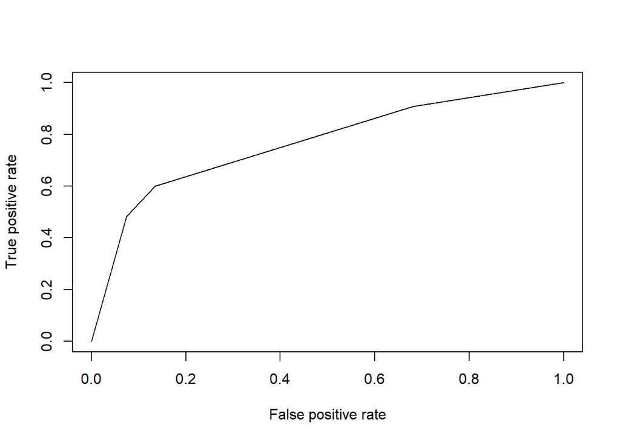

```r
set.seed(404)
pred <- prediction(predictions_4,test$y)
roc <- performance(pred, measure="tpr", x.measure="fpr")
plot(roc)
```

```r
cat("auc =", round(performance(pred,measure="auc")@y.values[[1]],3))
```

```
## auc = 0.767
```